# Mini-Project 01

# Data Visualization Project 01

For this mini project **“Analysis on Motor Vehicle Collisions in Newyork”** , the dataset chosen from the “Motor vehicle collisions - vehicles” taken from U.S. Government’s open data

# **Introduction**

The “Motor Vehicle Collisions in Newyork” dataset is a comprehensive collection of data related to motor vehicle collisions involving various types of vehicles. This dataset provides valuable insights into the characteristics and outcomes of motor vehicle accidents, offering a foundation for analysis in the field of transportation safety.

# Loading Required libraries

```r
library(tidyverse)
```

```r
library(ggplot2)
library(viridis)
library(treemapify)
```

# Importing data

```r
collisions <- read_csv("C:/github/dataviz_final_project/data/Motor_Vehicle_Collisions_-_Vehicles.csv")
collisions
```

```
## # A tibble: 3,704,406 × 25
##    UNIQUE_ID COLLISION_ID CRASH_DATE CRASH_TIME VEHICLE_ID    STATE_REGISTRATION
##        <dbl>        <dbl> <chr>      <time>     <chr>         <chr>
##  1  10385780       100201 09/07/2012 09:03      1             NY
##  2  19140702      4213082 09/23/2019 08:15      0553ab4d-950… NY
##  3  14887647      3307608 10/02/2015 17:18      2             NY
##  4  14889754      3308693 10/04/2015 20:34      1             NY
##  5  14400270       297666 04/25/2013 21:15      1             NY
##  6  17044639      3434155 05/02/2016 17:35      219456        NY
##  7  19138701      4229067 10/24/2019 13:15      c53b43d9-419… NY
##  8  17303317      3503027 08/18/2016 12:39      672828        NY
##  9  12254536       196425 07/16/2013 11:20      1             NY
## 10  11804847      2975897 11/26/2012 18:12      2             NY
## # ℹ 3,704,396 more rows
## # ℹ 19 more variables: VEHICLE_TYPE <chr>, VEHICLE_MAKE <chr>,
## #   VEHICLE_MODEL <chr>, VEHICLE_YEAR <dbl>, TRAVEL_DIRECTION <chr>,
## #   VEHICLE_OCCUPANTS <dbl>, DRIVER_SEX <chr>, DRIVER_LICENSE_STATUS <chr>,
## #   DRIVER_LICENSE_JURISDICTION <chr>, PRE_CRASH <chr>, POINT_OF_IMPACT <chr>,
## #   VEHICLE_DAMAGE <chr>, VEHICLE_DAMAGE_1 <chr>, VEHICLE_DAMAGE_2 <chr>,
## #   VEHICLE_DAMAGE_3 <chr>, PUBLIC_PROPERTY_DAMAGE <chr>, …
```

# **Data Description**

The dataset encompasses a wide range of information about vehicles involved in motor vehicle collisions, with a focus on the United States. It offers a rich and diverse collection of data points that enable to delve into the intricacies of motor vehicle accidents and derive meaningful conclusions.It is regularly updated, ensuring access to the most recent and relevant information.

```r
summary(collisions)
```

```
##    UNIQUE_ID         COLLISION_ID      CRASH_DATE         CRASH_TIME
##  Min.   :  111711   Min.   :     22   Length:3704406     Length:3704406
##  1st Qu.:14215160   1st Qu.:3017853   Class :character   Class1:hms
##  Median :17306058   Median :3567068   Mode  :character   Class2:difftime
##  Mean   :16060871   Mean   :2996659                      Mode  :numeric
##  3rd Qu.:18739205   3rd Qu.:4028145
##  Max.   :20121717   Max.   :4484197
##
##   VEHICLE_ID        STATE_REGISTRATION VEHICLE_TYPE       VEHICLE_MAKE
##  Length:3704406     Length:3704406     Length:3704406     Length:3704406
##  Class :character   Class :character   Class :character   Class :character
##  Mode  :character   Mode  :character   Mode  :character   Mode  :character
##
##
##
##
##  VEHICLE_MODEL       VEHICLE_YEAR     TRAVEL_DIRECTION   VEHICLE_OCCUPANTS
##  Length:3704406     Min.   : 1000     Length:3704406     Min.   :0.00e+00
##  Class :character   1st Qu.: 2008     Class :character   1st Qu.:1.00e+00
##  Mode  :character   Median : 2013     Mode  :character   Median :1.00e+00
##                     Mean   : 2015                        Mean   :1.01e+03
##                     3rd Qu.: 2016                        3rd Qu.:1.00e+00
##                     Max.   :20063                        Max.   :1.00e+09
##                     NA's   :1796971                      NA's   :1718406
##   DRIVER_SEX        DRIVER_LICENSE_STATUS DRIVER_LICENSE_JURISDICTION
##  Length:3704406     Length:3704406        Length:3704406
##  Class :character   Class :character      Class :character
##  Mode  :character   Mode  :character      Mode  :character
##
##
##
##
##   PRE_CRASH         POINT_OF_IMPACT    VEHICLE_DAMAGE     VEHICLE_DAMAGE_1
##  Length:3704406     Length:3704406     Length:3704406     Length:3704406
##  Class :character   Class :character   Class :character   Class :character
##  Mode  :character   Mode  :character   Mode  :character   Mode  :character
##
##
##
##
##  VEHICLE_DAMAGE_2   VEHICLE_DAMAGE_3   PUBLIC_PROPERTY_DAMAGE
##  Length:3704406     Length:3704406     Length:3704406
##  Class :character   Class :character   Class :character
##  Mode  :character   Mode  :character   Mode  :character
##
##
##
##
##  PUBLIC_PROPERTY_DAMAGE_TYPE CONTRIBUTING_FACTOR_1 CONTRIBUTING_FACTOR_2
##  Length:3704406              Length:3704406        Length:3704406
##  Class :character            Class :character      Class :character
##  Mode  :character            Mode  :character      Mode  :character
##
##
##
##
```

# Structure of the data

```r
str(collisions)
```

```
## spc_tbl_ [3,704,406 × 25] (S3: spec_tbl_df/tbl_df/tbl/data.frame)
##  $ UNIQUE_ID                  : num [1:3704406] 10385780 19140702 14887647 14889754 14400270 ...
##  $ COLLISION_ID               : num [1:3704406] 100201 4213082 3307608 3308693 297666 ...
##  $ CRASH_DATE                 : chr [1:3704406] "09/07/2012" "09/23/2019" "10/02/2015" "10/04/2015" ...
##  $ CRASH_TIME                 : 'hms' num [1:3704406] 09:03:00 08:15:00 17:18:00 20:34:00 ...
##   ..- attr(*, "units")= chr "secs"
##  $ VEHICLE_ID                 : chr [1:3704406] "1" "0553ab4d-9500-4cba-8d98-f4d7f89d5856" "2" "1" ...
##  $ STATE_REGISTRATION         : chr [1:3704406] "NY" "NY" "NY" "NY" ...
##  $ VEHICLE_TYPE               : chr [1:3704406] "PASSENGER VEHICLE" "Station Wagon/Sport Utility Vehicle" "TAXI" "PASSENGER VEHICLE" ...
##  $ VEHICLE_MAKE               : chr [1:3704406] NA "TOYT -CAR/SUV" NA NA ...
##  $ VEHICLE_MODEL              : chr [1:3704406] NA NA NA NA ...
##  $ VEHICLE_YEAR               : num [1:3704406] NA 2002 NA NA NA ...
##  $ TRAVEL_DIRECTION           : chr [1:3704406] NA "North" NA NA ...
##  $ VEHICLE_OCCUPANTS          : num [1:3704406] NA 1 NA NA NA 2 13 2 NA NA ...
##  $ DRIVER_SEX                 : chr [1:3704406] NA "M" NA NA ...
##  $ DRIVER_LICENSE_STATUS      : chr [1:3704406] NA "Licensed" NA NA ...
##  $ DRIVER_LICENSE_JURISDICTION: chr [1:3704406] NA "NY" NA NA ...
##  $ PRE_CRASH                  : chr [1:3704406] NA "Going Straight Ahead" "Going Straight Ahead" "Parked" ...
##  $ POINT_OF_IMPACT            : chr [1:3704406] NA "Left Front Bumper" NA NA ...
##  $ VEHICLE_DAMAGE             : chr [1:3704406] NA "Left Front Quarter Panel" NA NA ...
##  $ VEHICLE_DAMAGE_1           : chr [1:3704406] NA NA NA NA ...
##  $ VEHICLE_DAMAGE_2           : chr [1:3704406] NA NA NA NA ...
##  $ VEHICLE_DAMAGE_3           : chr [1:3704406] NA NA NA NA ...
##  $ PUBLIC_PROPERTY_DAMAGE     : chr [1:3704406] NA "N" NA NA ...
##  $ PUBLIC_PROPERTY_DAMAGE_TYPE: chr [1:3704406] NA NA NA NA ...
##  $ CONTRIBUTING_FACTOR_1      : chr [1:3704406] "Unspecified" "Driver Inattention/Distraction" "Driver Inattention/Distraction" "Unspecified" ...
##  $ CONTRIBUTING_FACTOR_2      : chr [1:3704406] NA "Unspecified" NA NA ...
##  - attr(*, "spec")=
##   .. cols(
##   ..   UNIQUE_ID = col_double(),
##   ..   COLLISION_ID = col_double(),
##   ..   CRASH_DATE = col_character(),
##   ..   CRASH_TIME = col_time(format = ""),
##   ..   VEHICLE_ID = col_character(),
##   ..   STATE_REGISTRATION = col_character(),
##   ..   VEHICLE_TYPE = col_character(),
##   ..   VEHICLE_MAKE = col_character(),
##   ..   VEHICLE_MODEL = col_character(),
##   ..   VEHICLE_YEAR = col_double(),
##   ..   TRAVEL_DIRECTION = col_character(),
##   ..   VEHICLE_OCCUPANTS = col_double(),
##   ..   DRIVER_SEX = col_character(),
##   ..   DRIVER_LICENSE_STATUS = col_character(),
##   ..   DRIVER_LICENSE_JURISDICTION = col_character(),
##   ..   PRE_CRASH = col_character(),
##   ..   POINT_OF_IMPACT = col_character(),
##   ..   VEHICLE_DAMAGE = col_character(),
##   ..   VEHICLE_DAMAGE_1 = col_character(),
##   ..   VEHICLE_DAMAGE_2 = col_character(),
##   ..   VEHICLE_DAMAGE_3 = col_character(),
##   ..   PUBLIC_PROPERTY_DAMAGE = col_character(),
##   ..   PUBLIC_PROPERTY_DAMAGE_TYPE = col_character(),
##   ..   CONTRIBUTING_FACTOR_1 = col_character(),
##   ..   CONTRIBUTING_FACTOR_2 = col_character()
##   .. )
##  - attr(*, "problems")=<externalptr>
```

# Motor vehicle collisions rate by Month and Year

```r
monthly_collisions <- collisions %>%
  mutate(Date = as.Date(CRASH_DATE, format = "%m/%d/%Y")) %>%
  group_by(Year = format(Date, "%Y"), Month = format(Date, "%b")) %>%
  summarise(NumCollisions = n()) %>%
  arrange(Year, match(Month, month.abb))
monthly_collisions
```

```
## # A tibble: 114 × 3
## # Groups:   Year [10]
##    Year  Month NumCollisions
##    <chr> <chr>         <int>
##  1 2012  Jul           33887
##  2 2012  Aug           34235
##  3 2012  Sep           32835
##  4 2012  Oct           33140
##  5 2012  Nov           31229
##  6 2012  Dec           33642
##  7 2013  Jan           30876
##  8 2013  Feb           28351
##  9 2013  Mar           32813
## 10 2013  Apr           32722
## # ℹ 104 more rows
```

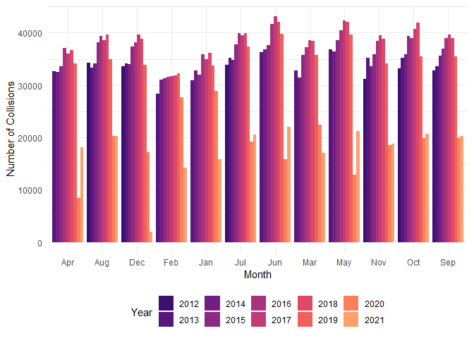

```r
ggplot(monthly_collisions, aes(x = Month, y = NumCollisions, fill = Year)) +
  geom_col(position = "dodge") +
  theme_minimal() +
  labs(x = "Month", y = "Number of Collisions", fill = "Year") +
  scale_fill_viridis_d(option = "A", begin = 0.2, end = 0.8) +
  theme(legend.position = "bottom")
```

Here, it groups the data by year and month, counting the number of collisions in each month. The resulting data is then plotted using ggplot, showing the number of collisions per month, with each year represented by a different color. The color scheme used is viridis, and the legend is positioned at the bottom of the plot

What were the original charts you planned to create for this visualization?

The original charts planned for this project were bar charts showing the number of motor vehicle collisions by month and year. The x-axis represented the months, the y-axis represented the number of collisions, and the bars were grouped by year.

What story could you tell with your plot?

With these plots,I can tell about the variation in motor vehicle collision rates over time. By observing the bars’ heights for each month, we can identify patterns and trends in collision rates across different years. Highlighting months with higher or lower collision rates and compare them across multiple years. This could lead to insights such as identifying seasonal patterns or determining if collision rates have been increasing or decreasing over time.

# Collisions by time of day

I have examined the collisions by time of day

```r
collision_times <- collisions %>%
  group_by(CRASH_TIME) %>%
  summarise(NumCollisions = n()) %>%
  arrange(desc(NumCollisions))
collision_times
```

```
## # A tibble: 1,440 × 2
##    CRASH_TIME NumCollisions
##    <time>             <int>
##  1 16:00              53106
##  2 17:00              52004
##  3 15:00              51254
##  4 18:00              47734
##  5 14:00              47067
##  6 13:00              43799
##  7 09:00              39641
##  8 19:00              39188
##  9 12:00              39113
## 10 16:30              38565
## # ℹ 1,430 more rows
```

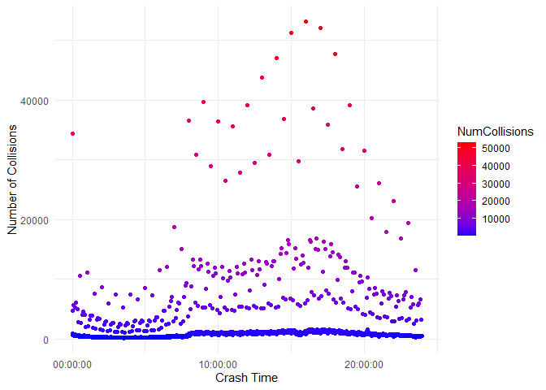

```r
# Create a scatterplot
ggplot(collision_times, aes(x = CRASH_TIME, y = NumCollisions, color = NumCollisions)) +
  geom_point() +
  scale_color_gradient(low = "blue", high = "red") +
  labs(x = "Crash Time", y = "Number of Collisions") +
  theme_minimal()
```

The resulting plot allows for a visual analysis of the distribution of collisions throughout the crash times, helping identify any patterns or trends in the data.

What were the original charts you planned to create for this assignments?

The original charts planned to be created for this assignment is a scatter plot showing the number of collisions (NumCollisions) on the y-axis and the crash times (CRASH_TIME) on the x-axis. Each point on the plot would represent a specific crash time, and the color of the points would be based on the number of collisions at that time.The purpose of this chart is to visualize the distribution of collisions across different crash times and identify any patterns or trends in the data.

What story could you tell with your plots?

The story that could be told with these plots is the scatter plot can provide insights into the frequency of collisions at different crash times. By examining the distribution of points, we can identify if certain times of the day or specific periods have a higher number of collisions. This information can be useful for understanding when and where accidents are more likely to occur, allowing for targeted interventions and improved road safety measures.

How did you apply the principles of data visualizations and design for this assignment?

The principles of data visualization and design applied in this assignment include:

1.Choosing an appropriate visualization: The scatter plot is suitable for showing the relationship between two continuous variables (crash time and number of collisions). It allows for the identification of patterns or clusters in the data.

2.Color mapping: The color of the points in the scatter plot is mapped to the number of collisions at each crash time. The use of a color gradient from blue to red helps to visually represent the varying intensities of collisions, with blue indicating fewer collisions and red indicating a higher number of collisions.

3.Axis labeling and title: The x-axis is labeled as “Crash Time” and the y-axis as “Number of Collisions.” This provides clear information about the variables being represented in the plot. The title of the plot can further enhance understanding by summarizing the main purpose of the visualization.

4.Minimalist theme: The plot is styled with a minimalistic theme using `theme_minimal()`. This ensures that the focus remains on the data and reduces any distractions or unnecessary visual elements.

# Distribution of collisions by Vehicle type

```r
top_collisions <- collisions %>%
  group_by(VEHICLE_TYPE) %>%
  summarise(NumCollisions = n()) %>%
  arrange(desc(NumCollisions)) %>%
  top_n(10)
top_collisions
```

```
## # A tibble: 10 × 2
##    VEHICLE_TYPE                        NumCollisions
##    <chr>                                       <int>
##  1 Sedan                                      859697
##  2 PASSENGER VEHICLE                          770756
##  3 Station Wagon/Sport Utility Vehicle        692408
##  4 SPORT UTILITY / STATION WAGON              337927
##  5 <NA>                                       177788
##  6 UNKNOWN                                    105415
##  7 Taxi                                        82816
##  8 4 dr sedan                                  73447
##  9 TAXI                                        60785
## 10 Pick-up Truck                               59322
```

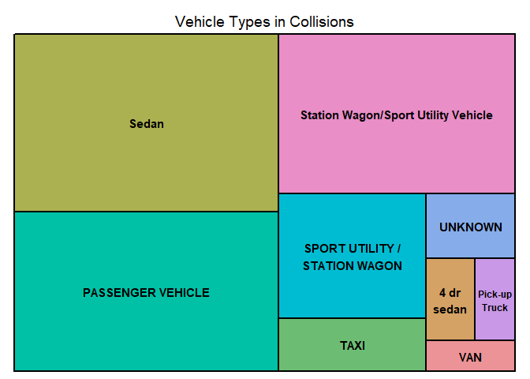

```r
library(treemap)
# Combine similar vehicle types
collisions$VEHICLE_TYPE <- ifelse(grepl("TAXI", collisions$VEHICLE_TYPE, ignore.case = TRUE), "TAXI", collisions$VEHICLE_TYPE)

# Group and summarize collisions by vehicle type
top_collisions <- collisions %>%
  group_by(VEHICLE_TYPE) %>%
  summarise(NumCollisions = n()) %>%
  arrange(desc(NumCollisions)) %>%
  top_n(10)
# Create treemap
treemap(top_collisions, index = "VEHICLE_TYPE", vSize = "NumCollisions",
        title = "Vehicle Types in Collisions")
```

What were the original charts you planned to create for this assignments?

The original plan was to create a treemap to visualize the distribution of collisions by vehicle type.

What story could you tell with your plots?

With the treemap visualization, we can tell a story about the relative frequency of different vehicle types involved in collisions. The treemap displays the vehicle types as rectangles, where the size of each rectangle represents the number of collisions associated with that vehicle type. By examining the treemap, we can quickly identify the vehicle types that are most commonly involved in collisions.

How did you apply the principles of data visualizations and design for this assignment?

To apply the principles of data visualizations and design, it’s important to consider the following:

- Choosing appropriate chart types: The treemap is suitable for displaying the distribution of collisions by vehicle type, as they effectively represent categorical data and allow for comparisons.
- Clear labeling: Ensure that the axes and labels in the chart are properly labeled, making it easy for the audience to understand the information being presented.
- Color choices: Select colors that are visually appealing and facilitate easy differentiation between categories or vehicle types. Use a consistent color scheme throughout the visualizations.
- Layout and presentation: Arrange the charts in a visually pleasing and logical manner. Add titles, captions, or annotations to provide context and guide the audience through the story being told.
- Data integrity: Verify that the data used for the visualizations is accurate and reliable. Any data manipulation or grouping should be performed appropriately to ensure the visualizations accurately represent the underlying information.

By applying these principles, the visualizations would effectively communicate the distribution of collisions by vehicle type, enabling the audience to grasp the main insights and trends at a glance